# Assignment03 VIS

Jessica Tang

9/30/2020

**Libraries:**

```r
library(sf)
library(tidyverse)
library(ggthemes)
library(ggspatial)
library(units)
library(nngeo)
library(cartogram)
library(compare)
# library(RSocrata) I could only access .json files with this API, so I had to download the .geojson files
# library(ggmap)
```

## Issues I will be Submitting

I know my Assignment has several issues and am anticipating that my grade on this will reflect that. But I am eager to find out what I did wrong.

- Q1 and Q2: discrepancies with my original datasets and my joined datasets (will submit in Github)
- Q3: could not calculate distances – I printed the error a the bottom of this Rmd (will submit in Github)
- I tried using `coord_sf(xlim, ylim)` to crop my map, but I got a bad map like the one [this person on Github](https://github.com/tidyverse/ggplot2/issues/2090) asked about and I couldn’t figure it out (will submit in Github and/or do more Googling)
- I don’t know if my Dorling cartograms are effective or misleading

Also this is my fault but I worked off an older syllabus, the one that asked for 8 plots and 15 possible combinations.

## Loading & Transforming Data

I got data from [NYC’s Open Data portal](https://opendata.cityofnewyork.us/). I wanted to see if I were at a park or public plaza, where I would find two things – Internet and water.

I chose EPSG:2263 for New York City. Units are in feet. More info at [SpatialReference.org](https://spatialreference.org/ref/epsg/2263/) and [EPSG.io](https://epsg.io/2263).

- 0 = Borough boundaries (polygon)
- A = WiFi hotspots (point)
- B = drinking fountains (point)
- C = parks (polygon)
- D = public plazas (polygon)

```r
nyc_epsg2263 <- "+proj=lcc +lat_1=41.03333333333333 +lat_2=40.66666666666666 +lat_0=40.16666666666666 +lon_0=-74 +x_0=300000.0000000001 +y_0=0 +ellps=GRS80 +datum=NAD83 +to_meter=0.3048006096012192 +no_defs"

nyc <- st_read("Borough Boundaries.geojson") %>%
  st_transform(nyc_epsg2263)

wifi <- st_read("NYC Wi-Fi Hotspot Locations.geojson") %>%
  st_transform(nyc_epsg2263)

fountains <- st_read("NYC Parks Drinking Fountains.geojson") %>%
  st_transform(nyc_epsg2263)

parks <- st_read("Open Space (Parks).geojson") %>%
  st_transform(nyc_epsg2263)

plazas <- st_read("Public Plazas.geojson") %>%
  st_transform(nyc_epsg2263)
```

## General Plot

(You can’t really see the plazas)

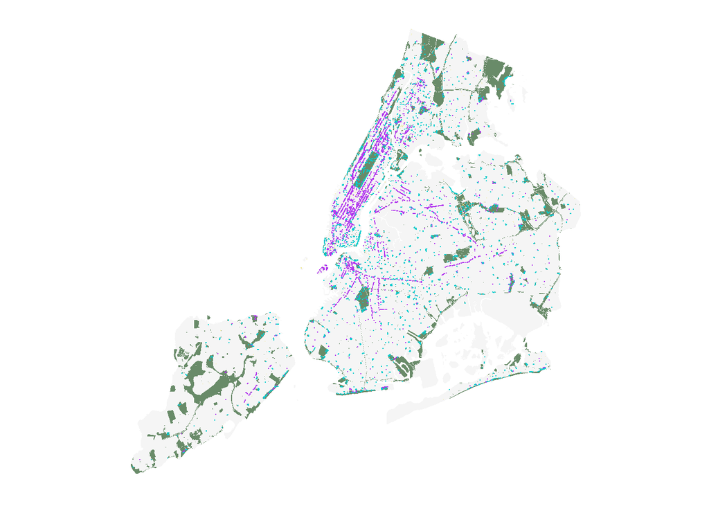

```r
ggplot() +
  geom_sf(data = nyc, fill = "gray96", color = NA) +
  geom_sf(data = parks, fill = "darkseagreen4", color = NA) +
  geom_sf(data = plazas, fill = "khaki2", color = NA) +
  geom_sf(data = wifi, color = "darkorchid2", size = 0.01) +
  geom_sf(data = fountains, color = "cyan3", size = 0.1) +
  theme_map()
```